# mir181 binding sites - union of mir181 enriched binding sites and Ago binding sites targeted by mir181

Melina Klostermann

20 September, 2023

# 1 Libraries and settings

```r
# ----------------------------------------
# libraries
# ----------------------------------------
library(tidyverse)
library(GenomicRanges)
library(colorspace)
library(eulerr)
library(gghalves)
library(ggpubr)

# ----------------------------------------
# settings
# ----------------------------------------
here <- here::here()
out <- paste0(here,"/Figure2/02_compare_miR_enriched_to_Ago_binding_sites/")

source(paste0(here,"/Supporting_scripts/themes/theme_paper.R"))
source(paste0(here,"/Supporting_scripts/themes/CustomThemes.R"))

# #nikita
# out <- "D:/Krueger_Lab/Publications/miR181_paper/Figure1/mir181_binding_sites__venn_types/"
# source("D:/Krueger_Lab/Publications/miR181_paper/Supporting_scripts/themes/theme_paper.R")
# source("D:/Krueger_Lab/Publications/miR181_paper/Supporting_scripts/themes/CustomThemes.R")

# farben
farbeneg <- "#B4B4B4"
farbe1 <- "#0073C2FF" #WT farbe
farbe2 <- "#EFC000FF"
farbe4 <- "#7AA6DCFF"
farbe6 <- "#003C67FF"
farbe14 <- "#8A4198FF"
```

# 2 What was done?

# 3 Files

```r
# ----------------------------------------
# mir181 enriched binding sites
# ----------------------------------------
mir181_enriched <- readRDS(paste0(here,"/Figure2/01_mir181-enriched_binding_site_definition/BS_mir181_enriched.rds"))

# #nikita
# mir181_enriched <- readRDS("D:/Krueger_Lab/Publications/miR181_paper/Methods/mir181-enriched_binding_site_definition/2023-04-03-BS_mir181_enriched.rds")

# ----------------------------------------
# chimeric reads
# ----------------------------------------

chimeric_reads <- readRDS(paste0(here,"/Figure1/02_Ago_targetome/mir_chimeric_crosslinks.rds"))

#nikita
# chimeric_reads <- readRDS("D:/Krueger_Lab/Publications/miR181_paper/Figure1/Ago_targetome/mir_chimeric_crosslinks.rds")

# ----------------------------------------
# AGO binding sites
# ----------------------------------------
ago_bs <- readRDS(paste0(here,"/Figure1/01_AGO_binding_site_definition/AGO_BS.rds"))

#nikita
# ago_bs <- readRDS("D:/Krueger_Lab/Publications/miR181_paper/Figure1/AGO_binding_site_definition/2023-04-21-AGO_BS.rds")

# ----------------------------------------
# BS downregulated in mir181 KO
# ----------------------------------------
diff <- readRDS(paste0(here,"/Figure2/04_Differential_Binding/BsDifferentialResult.rds"))

#nikita
# diff <- readRDS("D:/Krueger_Lab/Publications/miR181_paper/Figure1/Differential_Binding/BsDifferentialResult.rds")
```

# 4 mir181 binding sites

## 4.1 Get AGO binding sites with chimeric mir181

```r
# use region of bs +-10nt for overlaps
ago_bs_10 <- ago_bs + 10

# use chimeric reads from both mir181 enriched and non-enriched data
chimeric_reads <- c(makeGRangesFromDataFrame(chimeric_reads$IP_WT, keep.extra.columns = T), makeGRangesFromDataFrame(chimeric_reads$IP_WT_miR181, keep.extra.columns = T) )

# find overlaps of mirt and AGO bs
idx <- findOverlaps(ago_bs_10, chimeric_reads )

# make a data frame from the ago bs
names(ago_bs)<- 1:NROW(ago_bs)
ago_bs <- as.data.frame(ago_bs)
ago_bs$BS_ID <- rownames(ago_bs)

# add mir info to ago bs
ago_bs_mir181_chi <- cbind(ago_bs[queryHits(idx),], mir_IP = chimeric_reads [subjectHits(idx),]$Name)

ago_bs_mir181_chi <- ago_bs_mir181_chi[grepl(ago_bs_mir181_chi$mir_IP,
                                       pattern = "miR-181"),]

# count chimerics
mir181_chi <- ago_bs_mir181_chi %>% group_by(BS_ID) %>%
  summarize(n_mir181 = sum(grepl(mir_IP,pattern = "miR-181")),
            n_mir181a = sum(grepl(mir_IP,pattern = "miR-181a")),
            n_mir181b = sum(grepl(mir_IP,pattern = "miR-181b")),
            n_mir181c = sum(grepl(mir_IP,pattern = "miR-181c")),
            n_mir181d = sum(grepl(mir_IP,pattern = "miR-181d")),
            .groups = "keep") %>% subset (n_mir181 >0)

ago_bs_mir181_chi <- ago_bs_mir181_chi %>%
  subset(!duplicated(ago_bs_mir181_chi$BS_ID)) %>%
  left_join(., mir181_chi, by ="BS_ID") %>% makeGRangesFromDataFrame(keep.extra.columns = T)
```

## 4.2 Combine AGO binding sites with chimeric mir181 with mir181 enriched binding sites

I combine the mir181 Ago binding sites that we obtained above with the binding sites from the mir181 enriched Ago-eCLIP (see Methods/mir181-enriched_binding_site_definition). In order to do that, I first select binding sites from both conditions that do not overlap with any binding site from the other set. For the binding sites that overlap between the two conditions, I select the AGO mir181 binding sites and tag them as occuring in both sets. Then I combine the three subsets sets. The obtained union of mir181 binding sites from both conditions are our final mir181 binding sites.

```r
# ---------------------------
# combine mir181 Ago BS and mir181 enriched Bs
# --------------------------
# get only Ago mir181 Bs with now overlaps to enriched mir181 BS
only_ago_bs_mir181_chi <- subsetByOverlaps(ago_bs_mir181_chi, mir181_enriched, type = "any", invert = T)
only_ago_bs_mir181_chi$set <- "ago_bs_mir181_chi"

# get only enriched mir181 BS with now overlaps to Ago mir181 Bs
only_mir181_enriched <- subsetByOverlaps(mir181_enriched, ago_bs_mir181_chi,  type = "any", invert = T)
only_mir181_enriched$set <- "mir181_enriched"

# get only Ago mir181 BS overlapping with mir181 enriched BS
both_mir181_enriched_chi <- subsetByOverlaps(ago_bs_mir181_chi, mir181_enriched, type = "any")
both_mir181_enriched_chi$set <- "ago_bs_mir181_chi&mir181_enriched"

# combine all three sets
mir181_bs <- c(only_ago_bs_mir181_chi, only_mir181_enriched, both_mir181_enriched_chi)
mir181_bs$BS_ID <- NULL
mir181_bs$mir181BS_ID <- 1:NROW(mir181_bs)
```

# 5 pie chart mir181 enriched set - Figure 2b

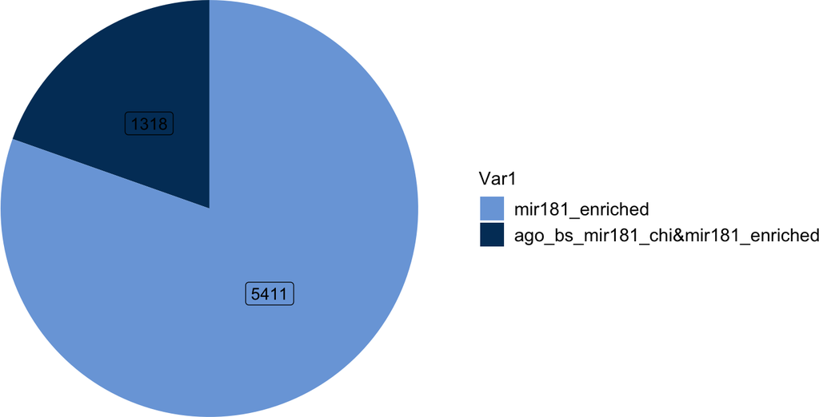

```r
# ----------------------------------------
# Compare Ago2 mir181 BS and mir181 enriched BS
# Figure 2 b
# ----------------------------------------

names(mir181_bs) <- 1:NROW(mir181_bs)

mir181_enriched_set <- mir181_bs %>%
  as.data.frame(.) %>%
  subset(set %in% c("ago_bs_mir181_chi&mir181_enriched", "mir181_enriched"))

mir181_enriched_set_df <-   table(mir181_enriched_set$set) %>%
  as.data.frame(.)

p <- ggplot(mir181_enriched_set_df, aes(y=Freq, x="", fill=Var1)) +
     geom_col()+
     coord_polar(theta="y") +
  #    xlim(c(2, 4)) +
  geom_label(aes( fill=Var1, label = Freq),
             position = position_stack(vjust = 0.5),
             show.legend = FALSE) +
  scale_fill_manual(values = c (farbe6, farbe4)) +
  theme_paper() +
  theme_nice_pie() +
  #theme(legend.position = "none") +
  guides(fill = guide_legend(reverse = TRUE)) +
  labs(y = NULL,
       x = NULL)
p
```

```r
ggsave(p, filename = paste0(out, "Figure2b_pie_miR181_enriched_BS.pdf"), width = unit(8, "cm"), height = unit(6,"cm"))
```

# 6 Combine mir181 binding sites with differntial binding sites

Next, I combine the obtained mir181 binding sites with the results we obtained from the differntial binding between AGO binding sites and AGO binding sites with mir181 KO (see script Figure1/Differntial_Binding_AGO_BS_mir181_KO).

```r
# ---------------------------
# combine with differential BS
# --------------------------
# get overlaps with diff binding
diff_overlap <- findOverlaps( mir181_bs, makeGRangesFromDataFrame(diff, keep.extra.columns = T) , type = "any", select = "first")
# add differential information to mir181 binding sites
 d <- diff[,9:48]
mcols(mir181_bs) <- cbind(mcols(mir181_bs), d[diff_overlap,])

# add only diff bs (these are Ago binding sites but not mir181 Binding sites)
diff_only <- subsetByOverlaps( makeGRangesFromDataFrame(diff, keep.extra.columns = T), mir181_bs , type = "any", invert = T)
mir181_bs_diff <- c(mir181_bs, diff_only)
names(mir181_bs_diff) <- 1:NROW(mir181_bs_diff)
mir181_bs_diff <- as.data.frame(mir181_bs_diff)
```

## 6.1 Differential binding both sets

Here I look at the overall binding changes between mir181 KO and WT for mir181 enriched binding sites and other Ago2 binding sites.

```r
mycomp <- list(c("miR-181 target", "Other"))
mir181_bs_diff[is.na(mir181_bs_diff$set), "set"] <- "Other"
table(mir181_bs_diff$set)
```

```
##
##                 ago_bs_mir181_chi ago_bs_mir181_chi&mir181_enriched
##                              7117                              1318
##                   mir181_enriched                             Other
##                              5411                             17499
```

```r
viodat <- mir181_bs_diff
viodat <- viodat[!(viodat$set == "ago_bs_mir181_chi"),]
viodat[!(viodat$set == "Other"), "set"] <- "miR-181 target"
table(viodat$set)
```

```
##
## miR-181 target          Other
##           6729          17499
```

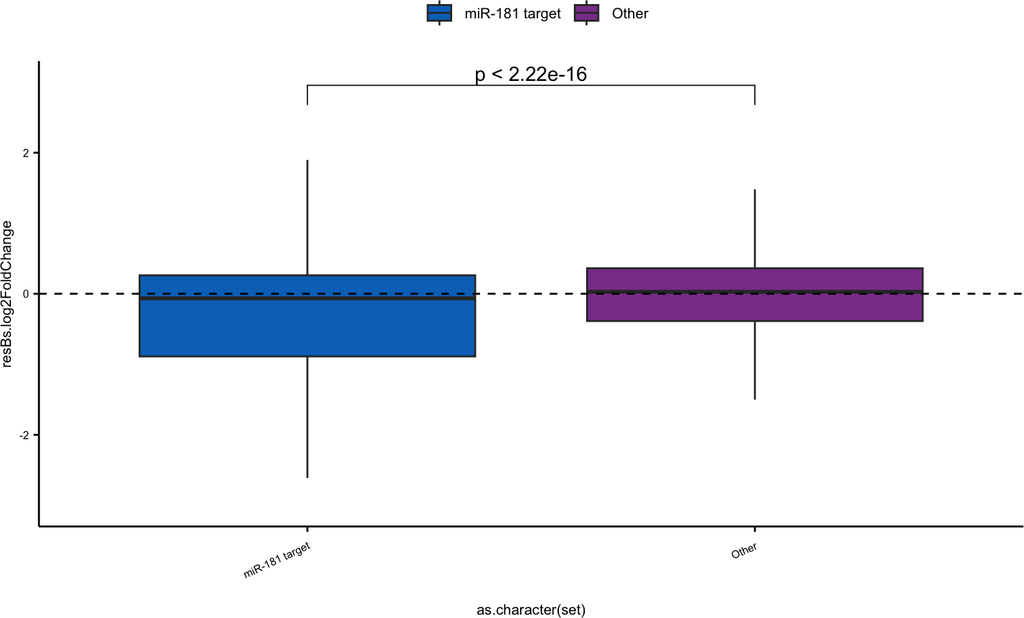

```r
p2n <- ggplot(viodat, aes(y = resBs.log2FoldChange, x = as.character(set), fill = as.character(set)))+
  geom_boxplot(outlier.shape = NA)+
  geom_hline(yintercept = 0, linetype="dashed") +
  theme_paper()+
  scale_fill_manual(values = c(farbe1, farbe14))+
  theme(legend.position = "top")+
  scale_x_discrete(guide = guide_axis(angle = 25)) +
  stat_compare_means(comparisons = mycomp, label.y = 2.5 ) +
  coord_cartesian(ylim = c(-3,3))

p2n
```

```r
ggsave(p2n, filename =  paste0(out, "Figure_2d_boxplot_differntial_binding_vs_mir181BS_pvalues.pdf"), width = 3.5, height = 7, units = "cm")
```

# 7 Save output

```r
saveRDS(mir181_bs, paste0(out, "mir181_bs.rds"))

t <- mir181_bs %>% as.data.frame() %>%
   subset(set %in% c("mir181_enriched", "ago_bs_mir181_chi&mir181_enriched"))

# Supplementary table 2
write_csv(t, paste0(out, "STable2_mir181_enriched_binding_sites.csv"))

table(mir181_bs$set)
```

```
##
##                 ago_bs_mir181_chi ago_bs_mir181_chi&mir181_enriched
##                              7117                              1318
##                   mir181_enriched
##                              5411
```